# NYPD_Shootings_Project

Vlad S

2022-08-01

```r
# Make sure these are installed:

# install.packages("tidyverse")
# install.packages("lubridate")
# install.packages("geosphere")
# install.packages("caTools")
# install.packages("randomForest")
# install.packages("class")

library(tidyverse)
library(lubridate)
library(geosphere)
library(caTools)
library(randomForest)
library(class)
```

## About the Data:

### Introduction:

- Our our initial or primary data set contains attributes surrounding every shooting incident in New York City since the year 2006 and all the way through until the end of the prior calendar year. This data is reviewed and updated every year by the Office of Management Analysis and Planning. In general, the information includes demographics surrounding the suspect as well as the victim, location and time of incident occurance, , as well as the label - which is a binary representation for whether the incident proved to be fatal for the victim.
- Our supporting data sets include additional information surround the police precincts such as the shape of the precinct in terms of area and length. Additionally, we will use a data set with supporting information about nearby hospitals. This data includes attributes such as facility type, borough, longitude and latitude. For our purposes, the attributes we are interested in are; [Precinct, Shape_Leng, Shape_Area, Facility Type, Borough, Latitude, Longitude]. We will be merging the data sets on Precinct and Borough respectively. We will be using hospital Latitude and Longitude (‘H_Latitude’ / ‘H_Longitude’) for distance calculation relative to incident location (in meters).

### Data Attributes (Combined):

- Independent Variables / Features:

  ```
    - INCIDENT_KEY
    - OCCUR_DATE
    - OCCUR_TIME
    - BORO
    - PRECINCT
    - JURISDICTION_CODE
    - LOCATION_DESC
    - PERP_AGE_GROUP
    - PERP_SEX
    - PERP_RACE
    - VIC_AGE_GROUP
    - VIC_SEX
    - VIC_RACE
    - X_COORD_CD
    - Y_COORD_CD
    - Latitude
    - Longitude
    - Shape_Area
    - Shape_Length
    - H_Latitude
    - H_Longitude
  ```

- Dependent / Target Variable:

  ```
    - STATISTICAL_MURDER_FLAG
  ```

- Columns we are interested in:

  ```
    - raw_dat1: [INCIDENT_KEY,OCCUR_DATE,OCCUR_TIME,BORO,PRECINCT,LOCATION_DESC,VIC_AGE_GROUP,VIC_SEX,VIC_RACE,Latitude,Longitude]

    - raw_dat2: [Precinct,Shape_Area,Shape_Length]

    - raw_dat3: [Facility Type,Borough,Latitude,Longitude]
  ```

## Importing Data:

First, we are going to import all the required data. Our primary data set is “raw_dat1”, and supporting data is in “raw_dat2” & “raw_dat1”.

```r
rd1 <- "https://data.cityofnewyork.us/api/views/833y-fsy8/rows.csv?accessType=DOWNLOAD"
raw_dat1 <- read_csv(rd1,col_select = c(INCIDENT_KEY,OCCUR_DATE,OCCUR_TIME,BORO,PRECINCT,LOCATION_DESC,VIC_AGE_GROUP,VIC_SEX,VIC_RACE,Latitude,Longitude,STATISTICAL_MURDER_FLAG))

rd2 <- "https://data.cityofnewyork.us/api/views/kmub-vria/rows.csv?accessType=DOWNLOAD"
raw_dat2 <- read_csv(rd2,col_select = c(Precinct,Shape_Area,Shape_Leng))

rd3 <- "https://data.cityofnewyork.us/api/views/ymhw-9cz9/rows.csv?accessType=DOWNLOAD"
raw_dat3 <- read_csv(rd3,col_select = c('Facility Type',Borough,Latitude,Longitude))
```

```r
# Lets take a quick look at our data sets.

head(raw_dat1,5)
```

```
## # A tibble: 5 × 12
##   INCIDENT_KEY OCCUR_DATE OCCUR_TIME BORO   PRECINCT LOCATION_DESC VIC_AGE_GROUP
##          <dbl> <chr>      <time>     <chr>     <dbl> <chr>         <chr>
## 1    236168668 11/11/2021 15:04      BROOK…       79 <NA>          18-24
## 2    231008085 07/16/2021 22:05      BROOK…       72 <NA>          25-44
## 3    230717903 07/11/2021 01:09      BROOK…       79 <NA>          25-44
## 4    237712309 12/11/2021 13:42      BROOK…       81 <NA>          25-44
## 5    224465521 02/16/2021 20:00      QUEENS      113 <NA>          25-44
## # … with 5 more variables: VIC_SEX <chr>, VIC_RACE <chr>, Latitude <dbl>,
## #   Longitude <dbl>, STATISTICAL_MURDER_FLAG <lgl>
```

```r
head(raw_dat2,5)
```

```
## # A tibble: 5 × 3
##   Precinct Shape_Area Shape_Leng
##      <dbl>      <dbl>      <dbl>
## 1        1  47286460.     80283.
## 2        5  18094527.     18807.
## 3        6  22103327.     26413.
## 4        7  18366670.     17288.
## 5        9  21395386.     19773.
```

```r
head(raw_dat3,5)
```

```
## # A tibble: 5 × 4
##   `Facility Type`     Borough   Latitude Longitude
##   <chr>               <chr>        <dbl>     <dbl>
## 1 Child Health Center Manhattan     NA        NA
## 2 Acute Care Hospital Queens        NA        NA
## 3 Child Health Center Brooklyn      40.6     -74.0
## 4 Child Health Center Queens        40.7     -73.8
## 5 Child Health Center Bronx         NA        NA
```

## Cleaning Data:

There are a few adjustments we need to make here:

[raw_dat1]

[raw_dat2]

1. Rename columns to: c(PRECINCT, AREA, LENGTH)
2. Merge with raw_dat1 on ‘PRECINCT’

[raw_dat3]

1. Drop all rows with missing Latitude.
2. Filter for Acute Care - Facility Type.
3. Rename columns to: ‘fType’,‘BORO’,‘H_Latitude’,‘H_Longitude’.
4. Replacing two Acute Care hospitals manually, due to missing Lat/Long on the original data file.
5. Convert boroughs to upper-case to match original raw_dat1 for merge.
6. Check for and remove any duplicate rows.
7. Merge raw_dat3 with the newly created file in prior merge.

```r
raw_dat1 <- raw_dat1 %>%
  mutate(OCCUR_DATE = lubridate::mdy(OCCUR_DATE),
         YEAR = year(OCCUR_DATE),
         HOUR = hour(OCCUR_TIME),
         TARGET = if_else(STATISTICAL_MURDER_FLAG==TRUE,1,0),
         VIC_SEX_M = if_else(VIC_SEX=='M',1,0),
         PVT_HOUSE = if_else(LOCATION_DESC=='PVT_HOUSE',1,0),
         HOTEL_MOTEL = if_else(LOCATION_DESC=='HOTEL/MOTEL',1,0),
         MULTI_PUB_HOU = if_else(LOCATION_DESC=='MULTI DWELL - PUBLIC HOUS',1,0),
         MULTI_APT = if_else(LOCATION_DESC=='MULTI DWELL - APT',1,0),
         BAR_CLUB = if_else(LOCATION_DESC=='BAR/NIGHT CLUB',1,0),
         VC_AGE_18 = if_else(VIC_AGE_GROUP=="<18",1,0),
         VC_AGE_18_24 = if_else(VIC_AGE_GROUP=="18-24",1,0),
         VC_AGE_25_44 = if_else(VIC_AGE_GROUP=='25_44',1,0),
         VC_AGE_65 = if_else(VIC_AGE_GROUP=='65+',1,0))

raw_dat1$MULTI_APT[is.na(raw_dat1$MULTI_APT)] <- 0
raw_dat1$PVT_HOUSE[is.na(raw_dat1$PVT_HOUSE)] <- 0
raw_dat1$HOTEL_MOTEL[is.na(raw_dat1$HOTEL_MOTEL)] <- 0
raw_dat1$MULTI_PUB_HOU[is.na(raw_dat1$MULTI_PUB_HOU)] <- 0
raw_dat1$BAR_CLUB[is.na(raw_dat1$BAR_CLUB)] <- 0

clean_dat1 <- raw_dat1 %>%
  select(TARGET,INCIDENT_KEY,PRECINCT,OCCUR_DATE,YEAR,HOUR,BORO,Latitude,Longitude
         ,VIC_SEX_M,PVT_HOUSE,HOTEL_MOTEL,MULTI_PUB_HOU,MULTI_APT,BAR_CLUB
         ,VC_AGE_18,VC_AGE_18_24,VC_AGE_25_44,VC_AGE_65)
```

```r
# Lets take a look at our cleaned primary data set.

head(clean_dat1,5)
```

```
## # A tibble: 5 × 19
##   TARGET INCIDENT_KEY PRECINCT OCCUR_DATE  YEAR  HOUR BORO    Latitude Longitude
##    <dbl>        <dbl>    <dbl> <date>     <dbl> <int> <chr>      <dbl>     <dbl>
## 1      0    236168668       79 2021-11-11  2021    15 BROOKL…     40.7     -74.0
## 2      0    231008085       72 2021-07-16  2021    22 BROOKL…     40.6     -74.0
## 3      0    230717903       79 2021-07-11  2021     1 BROOKL…     40.7     -74.0
## 4      0    237712309       81 2021-12-11  2021    13 BROOKL…     40.7     -73.9
## 5      0    224465521      113 2021-02-16  2021    20 QUEENS      40.7     -73.8
## # … with 10 more variables: VIC_SEX_M <dbl>, PVT_HOUSE <dbl>,
## #   HOTEL_MOTEL <dbl>, MULTI_PUB_HOU <dbl>, MULTI_APT <dbl>, BAR_CLUB <dbl>,
## #   VC_AGE_18 <dbl>, VC_AGE_18_24 <dbl>, VC_AGE_25_44 <dbl>, VC_AGE_65 <dbl>
```

```r
colnames(raw_dat2) = c('PRECINCT', 'AREA', 'LENGTH')

clean_dat2 <- left_join(clean_dat1,raw_dat2,by='PRECINCT')
```

```r
head(clean_dat2,5)
```

```
## # A tibble: 5 × 21
##   TARGET INCIDENT_KEY PRECINCT OCCUR_DATE  YEAR  HOUR BORO    Latitude Longitude
##    <dbl>        <dbl>    <dbl> <date>     <dbl> <int> <chr>      <dbl>     <dbl>
## 1      0    236168668       79 2021-11-11  2021    15 BROOKL…     40.7     -74.0
## 2      0    231008085       72 2021-07-16  2021    22 BROOKL…     40.6     -74.0
## 3      0    230717903       79 2021-07-11  2021     1 BROOKL…     40.7     -74.0
## 4      0    237712309       81 2021-12-11  2021    13 BROOKL…     40.7     -73.9
## 5      0    224465521      113 2021-02-16  2021    20 QUEENS      40.7     -73.8
## # … with 12 more variables: VIC_SEX_M <dbl>, PVT_HOUSE <dbl>,
## #   HOTEL_MOTEL <dbl>, MULTI_PUB_HOU <dbl>, MULTI_APT <dbl>, BAR_CLUB <dbl>,
## #   VC_AGE_18 <dbl>, VC_AGE_18_24 <dbl>, VC_AGE_25_44 <dbl>, VC_AGE_65 <dbl>,
## #   AREA <dbl>, LENGTH <dbl>
```

```r
raw_dat3 <- raw_dat3  %>%
  select('Facility Type','Borough','Latitude','Longitude') %>%
  drop_na('Latitude')
head(raw_dat3,5)
```

```
## # A tibble: 5 × 4
##   `Facility Type`     Borough  Latitude Longitude
##   <chr>               <chr>       <dbl>     <dbl>
## 1 Child Health Center Brooklyn     40.6     -74.0
## 2 Child Health Center Queens       40.7     -73.8
## 3 Child Health Center Queens       40.7     -73.8
## 4 Child Health Center Queens       40.7     -73.8
## 5 Child Health Center Queens       40.8     -73.9
```

```r
# Filtering for Acute Care - Facility Type
filt1 <- raw_dat3$`Facility Type`=='Acute Care Hospital'
raw_dat3 <- raw_dat3[filt1,]

# Renaming for ease of use.
colnames(raw_dat3) <- c('fType','BORO','H_Latitude','H_Longitude')

# Adding in two Acute Care Hospitals manually, due to Lat/Long issue.
raw_dat3 <- raw_dat3 %>% add_row(fType='Acute Care Hospital'
                                 ,BORO='Bronx'
                                 ,H_Latitude=40.817688484049
                                 ,H_Longitude=-73.924200271483)

raw_dat3  <- raw_dat3 %>% add_row(fType='Acute Care Hospital'
                                  ,BORO='Queens'
                                  ,H_Latitude=40.738710402563
                                  ,H_Longitude=-73.878351155182)
raw_dat3$BORO <- toupper(raw_dat3$BORO)
# Making sure that we did not create duplicates.
raw_dat3 <- distinct(raw_dat3)
```

```r
# Merge into final data set.
clean_dat3 <- left_join(clean_dat2,raw_dat3,by='BORO')
```

```r
head(clean_dat3,15)
```

```
## # A tibble: 15 × 24
##    TARGET INCIDENT_KEY PRECINCT OCCUR_DATE  YEAR  HOUR BORO   Latitude Longitude
##     <dbl>        <dbl>    <dbl> <date>     <dbl> <int> <chr>     <dbl>     <dbl>
##  1      0    236168668       79 2021-11-11  2021    15 BROOK…     40.7     -74.0
##  2      0    236168668       79 2021-11-11  2021    15 BROOK…     40.7     -74.0
##  3      0    236168668       79 2021-11-11  2021    15 BROOK…     40.7     -74.0
##  4      0    231008085       72 2021-07-16  2021    22 BROOK…     40.6     -74.0
##  5      0    231008085       72 2021-07-16  2021    22 BROOK…     40.6     -74.0
##  6      0    231008085       72 2021-07-16  2021    22 BROOK…     40.6     -74.0
##  7      0    230717903       79 2021-07-11  2021     1 BROOK…     40.7     -74.0
##  8      0    230717903       79 2021-07-11  2021     1 BROOK…     40.7     -74.0
##  9      0    230717903       79 2021-07-11  2021     1 BROOK…     40.7     -74.0
## 10      0    237712309       81 2021-12-11  2021    13 BROOK…     40.7     -73.9
## 11      0    237712309       81 2021-12-11  2021    13 BROOK…     40.7     -73.9
## 12      0    237712309       81 2021-12-11  2021    13 BROOK…     40.7     -73.9
## 13      0    224465521      113 2021-02-16  2021    20 QUEENS     40.7     -73.8
## 14      0    224465521      113 2021-02-16  2021    20 QUEENS     40.7     -73.8
## 15      1    228252164      113 2021-05-15  2021     4 QUEENS     40.7     -73.8
## # … with 15 more variables: VIC_SEX_M <dbl>, PVT_HOUSE <dbl>,
## #   HOTEL_MOTEL <dbl>, MULTI_PUB_HOU <dbl>, MULTI_APT <dbl>, BAR_CLUB <dbl>,
## #   VC_AGE_18 <dbl>, VC_AGE_18_24 <dbl>, VC_AGE_25_44 <dbl>, VC_AGE_65 <dbl>,
## #   AREA <dbl>, LENGTH <dbl>, fType <chr>, H_Latitude <dbl>, H_Longitude <dbl>
```

```r
tail(clean_dat3,15)
```

```
## # A tibble: 15 × 24
##    TARGET INCIDENT_KEY PRECINCT OCCUR_DATE  YEAR  HOUR BORO   Latitude Longitude
##     <dbl>        <dbl>    <dbl> <date>     <dbl> <int> <chr>     <dbl>     <dbl>
##  1      0    206524906       52 2019-12-14  2019    21 BRONX      40.9     -73.9
##  2      0    186329304       84 2018-08-12  2018    19 BROOK…     40.7     -74.0
##  3      0    186329304       84 2018-08-12  2018    19 BROOK…     40.7     -74.0
##  4      0    186329304       84 2018-08-12  2018    19 BROOK…     40.7     -74.0
##  5      0     29277330       81 2007-05-26  2007     4 BROOK…     40.7     -73.9
##  6      0     29277330       81 2007-05-26  2007     4 BROOK…     40.7     -73.9
##  7      0     29277330       81 2007-05-26  2007     4 BROOK…     40.7     -73.9
##  8      0     77443443       81 2011-02-25  2011     1 BROOK…     40.7     -73.9
##  9      0     77443443       81 2011-02-25  2011     1 BROOK…     40.7     -73.9
## 10      0     77443443       81 2011-02-25  2011     1 BROOK…     40.7     -73.9
## 11      0    176027888       43 2018-03-17  2018     0 BRONX      40.8     -73.9
## 12      0    176027888       43 2018-03-17  2018     0 BRONX      40.8     -73.9
## 13      0    176027888       43 2018-03-17  2018     0 BRONX      40.8     -73.9
## 14      0    218777493      113 2020-10-05  2020    12 QUEENS     40.7     -73.8
## 15      0    218777493      113 2020-10-05  2020    12 QUEENS     40.7     -73.8
## # … with 15 more variables: VIC_SEX_M <dbl>, PVT_HOUSE <dbl>,
## #   HOTEL_MOTEL <dbl>, MULTI_PUB_HOU <dbl>, MULTI_APT <dbl>, BAR_CLUB <dbl>,
## #   VC_AGE_18 <dbl>, VC_AGE_18_24 <dbl>, VC_AGE_25_44 <dbl>, VC_AGE_65 <dbl>,
## #   AREA <dbl>, LENGTH <dbl>, fType <chr>, H_Latitude <dbl>, H_Longitude <dbl>
```

## Transform Data

- Our final merge produced a file with duplicate incident keys. This is because some of the boroughs hold more than one Acute Care Hospital. In order to handle for this, we are going to apply the Haversine method to calculate the shortest distance between incident location and the surrounding hospitals using Latitude and Longitude of the incident and the hospitals. Finally, we retain the row in the data frame which contains the nearest hospital in relation to the incident location.
- In order to complete this, we are going to use the ‘distHaversine’ function within the ‘geosphere’ package.
- The new column containing the calculated shortest distance will be labeled as ‘H_dist’
- NOTE: Per the database, Staten Island does not have an Acute Care facility. This will be handled by assigning H_latitude and H_Longitude values to the closest Acute Care facility, in the closest borough [Brooklyn, (40.58655, -73.96617)]

```r
#clean_dat3
clean_dat4 <- clean_dat3 %>%
  mutate(H_Latitude = if_else(BORO=='STATEN ISLAND',40.58655,H_Latitude),
         H_Longitude = if_else(BORO=='STATEN ISLAND',-73.96617,H_Longitude),
         H_DIST = distHaversine(cbind(Longitude,Latitude),cbind(H_Longitude,H_Latitude)))
         #H_DIST = if_else(BORO=='STATEN ISLAND',mean(clean_dat4$H_DIST, na.rm = TRUE),H_DIST))
head(clean_dat4,5)
```

```
## # A tibble: 5 × 25
##   TARGET INCIDENT_KEY PRECINCT OCCUR_DATE  YEAR  HOUR BORO    Latitude Longitude
##    <dbl>        <dbl>    <dbl> <date>     <dbl> <int> <chr>      <dbl>     <dbl>
## 1      0    236168668       79 2021-11-11  2021    15 BROOKL…     40.7     -74.0
## 2      0    236168668       79 2021-11-11  2021    15 BROOKL…     40.7     -74.0
## 3      0    236168668       79 2021-11-11  2021    15 BROOKL…     40.7     -74.0
## 4      0    231008085       72 2021-07-16  2021    22 BROOKL…     40.6     -74.0
## 5      0    231008085       72 2021-07-16  2021    22 BROOKL…     40.6     -74.0
## # … with 16 more variables: VIC_SEX_M <dbl>, PVT_HOUSE <dbl>,
## #   HOTEL_MOTEL <dbl>, MULTI_PUB_HOU <dbl>, MULTI_APT <dbl>, BAR_CLUB <dbl>,
## #   VC_AGE_18 <dbl>, VC_AGE_18_24 <dbl>, VC_AGE_25_44 <dbl>, VC_AGE_65 <dbl>,
## #   AREA <dbl>, LENGTH <dbl>, fType <chr>, H_Latitude <dbl>, H_Longitude <dbl>,
## #   H_DIST <dbl>
```

```r
retain_date <- as.data.frame(clean_dat3[,c('INCIDENT_KEY','OCCUR_DATE','YEAR')])
colnames(retain_date) <- c('INCIDENT_KEY','DATE1','YEAR1')
retain_date <- distinct(retain_date)

clean_dat5 <- clean_dat4 %>%
  select(TARGET,INCIDENT_KEY,PRECINCT,OCCUR_DATE,YEAR,HOUR,BORO,Latitude,Longitude,VIC_SEX_M
         ,PVT_HOUSE,HOTEL_MOTEL,MULTI_PUB_HOU,MULTI_APT,BAR_CLUB
         ,VC_AGE_18,VC_AGE_18_24,VC_AGE_25_44,VC_AGE_65,AREA,LENGTH
         , H_DIST)%>%
  group_by(INCIDENT_KEY) %>%
  slice(which.min(H_DIST))

clean_dat6 <- left_join(retain_date,clean_dat5,by='INCIDENT_KEY')
# It looks like
clean_dat6 <- clean_dat6 %>% select(TARGET,INCIDENT_KEY,PRECINCT,OCCUR_DATE,YEAR,HOUR,BORO,Latitude,Longitude,VIC_SEX_M
         ,PVT_HOUSE,HOTEL_MOTEL,MULTI_PUB_HOU,MULTI_APT,BAR_CLUB
         ,VC_AGE_18,VC_AGE_18_24,VC_AGE_25_44,VC_AGE_65,AREA,LENGTH
         , H_DIST)
```

```r
# Lets check the data one more time.
head(clean_dat6,5)
```

```
##   TARGET INCIDENT_KEY PRECINCT OCCUR_DATE YEAR HOUR     BORO Latitude Longitude
## 1      0    236168668       79 2021-11-11 2021   15 BROOKLYN 40.68132 -73.95651
## 2      0    231008085       72 2021-07-16 2021   22 BROOKLYN 40.63636 -74.00867
## 3      0    230717903       79 2021-07-11 2021    1 BROOKLYN 40.68114 -73.95567
## 4      0    237712309       81 2021-12-11 2021   13 BROOKLYN 40.69579 -73.93910
## 5      0    224465521      113 2021-02-16 2021   20   QUEENS 40.67374 -73.76041
##   VIC_SEX_M PVT_HOUSE HOTEL_MOTEL MULTI_PUB_HOU MULTI_APT BAR_CLUB VC_AGE_18
## 1         1         0           0             0         0        0         0
## 2         1         0           0             0         0        0         0
## 3         1         0           0             0         0        0         0
## 4         1         0           0             0         0        0         0
## 5         1         0           0             0         0        0         0
##   VC_AGE_18_24 VC_AGE_25_44 VC_AGE_65      AREA    LENGTH   H_DIST
## 1            1            0         0  44975553  28256.93 2481.054
## 2            0            0         0 104512365  89340.42 5827.808
## 3            0            0         0  44975553  28256.93 2462.746
## 4            0            0         0  34485980  28386.93  568.146
## 5            0            0         0 387082870 197781.86 6049.106
```

```r
# Now that we confirmed our data looks good, lets only the necessary columns.

clean_dat7 <- clean_dat6 %>%
  select(TARGET,PRECINCT,YEAR,HOUR,BORO,Latitude,Longitude,VIC_SEX_M
         ,PVT_HOUSE,HOTEL_MOTEL,MULTI_PUB_HOU,MULTI_APT,BAR_CLUB
         ,VC_AGE_18,VC_AGE_18_24,VC_AGE_25_44,VC_AGE_65,AREA,LENGTH
         , H_DIST) %>%
  mutate(
    T1 = if_else(
      (HOUR>=0 & HOUR<3),1,0),
    T2 = if_else(
      (HOUR>=3 & HOUR<6),1,0),
    T3 = if_else(
      (HOUR>=6 & HOUR<9),1,0),
    T4 = if_else(
      (HOUR>=9 & HOUR<12),1,0),
    T5 = if_else(
      (HOUR>=12 & HOUR<15),1,0),
    T6 = if_else(
      (HOUR>=15 & HOUR<18),1,0),
    T7 = if_else(
      (HOUR>=18 & HOUR<21),1,0),
    T8 = if_else(
      (HOUR>=21 & HOUR<24),1,0),
    Tx = if_else(T1==1,'T1',
                 if_else(T2==1,'T2',
                         if_else(T3==1,'T3',
                                 if_else(T4==1,'T4',
                                         if_else(T5==1,'T5',
                                                 if_else(T6==1,'T6',
                                                         if_else(T7==1,'T7','T8')))))))) %>%
  mutate_at(vars(T1,T2,T3,T4,T5,T6,T7,T8,Tx,
                 VC_AGE_18,VC_AGE_18_24,VC_AGE_25_44,VC_AGE_65
             ,PVT_HOUSE,HOTEL_MOTEL,MULTI_PUB_HOU,MULTI_APT,BAR_CLUB
             ,VIC_SEX_M,TARGET),factor)



head(clean_dat7,5)
```

```
##   TARGET PRECINCT YEAR HOUR     BORO Latitude Longitude VIC_SEX_M PVT_HOUSE
## 1      0       79 2021   15 BROOKLYN 40.68132 -73.95651         1         0
## 2      0       72 2021   22 BROOKLYN 40.63636 -74.00867         1         0
## 3      0       79 2021    1 BROOKLYN 40.68114 -73.95567         1         0
## 4      0       81 2021   13 BROOKLYN 40.69579 -73.93910         1         0
## 5      0      113 2021   20   QUEENS 40.67374 -73.76041         1         0
##   HOTEL_MOTEL MULTI_PUB_HOU MULTI_APT BAR_CLUB VC_AGE_18 VC_AGE_18_24
## 1           0             0         0        0         0            1
## 2           0             0         0        0         0            0
## 3           0             0         0        0         0            0
## 4           0             0         0        0         0            0
## 5           0             0         0        0         0            0
##   VC_AGE_25_44 VC_AGE_65      AREA    LENGTH   H_DIST T1 T2 T3 T4 T5 T6 T7 T8
## 1            0         0  44975553  28256.93 2481.054  0  0  0  0  0  1  0  0
## 2            0         0 104512365  89340.42 5827.808  0  0  0  0  0  0  0  1
## 3            0         0  44975553  28256.93 2462.746  1  0  0  0  0  0  0  0
## 4            0         0  34485980  28386.93  568.146  0  0  0  0  1  0  0  0
## 5            0         0 387082870 197781.86 6049.106  0  0  0  0  0  0  1  0
##   Tx
## 1 T6
## 2 T8
## 3 T1
## 4 T5
## 5 T7
```

```r
# Transform all categoricals into factor type
cat_vars = c('T1','T2','T3','T4','T5','T6','T7','T8','Tx'
             ,'VC_AGE_18','VC_AGE_18_24','VC_AGE_25_44','VC_AGE_65'
             ,'PVT_HOUSE','HOTEL_MOTEL','MULTI_PUB_HOU','MULTI_APT','BAR_CLUB'
             ,'VIC_SEX_M','TARGET')


num_vars = c('Latitude','Longitude','AREA','LENGTH','H_DIST')

placeholders = c('PRECINCT','BORO','HOUR')
```

Next, we are going to split up our data set into a training and testing set in order to avoid introducing potential bias, the split will be 80% training and 20% for testing.

```r
train_set1=clean_dat7
# Secondary split - splitting data into training and validation
set.seed(123)
split_dat = sample.split(train_set1$TARGET, SplitRatio = 0.8)

train_set2 = subset(train_set1, split_dat == TRUE)
validation_set = subset(train_set1, split_dat == FALSE)

# Checking proportions

prop.table(table(train_set2$TARGET))
```

```
##
##         0         1
## 0.8249798 0.1750202
```

```r
prop.table(table(validation_set$TARGET))
```

```
##
##         0         1
## 0.8250932 0.1749068
```

## Visualize the Data

- Next, we are going to visualize our data within the training set as part of exploratory analysis.

```r
vis_dat <- train_set2[c(placeholders,cat_vars,num_vars)]
# Summary
summary(vis_dat)
```

```
##     PRECINCT          BORO                HOUR       T1        T2
##  Min.   :  1.00   Length:16101       Min.   : 0.00   0:12531   0:13876
##  1st Qu.: 44.00   Class :character   1st Qu.: 3.00   1: 3570   1: 2225
##  Median : 69.00   Mode  :character   Median :15.00
##  Mean   : 66.28                      Mean   :12.24
##  3rd Qu.: 81.00                      3rd Qu.:20.00
##  Max.   :123.00                      Max.   :23.00
##
##  T3        T4        T5        T6        T7        T8              Tx
##  0:15639   0:15528   0:14981   0:14329   0:13550   0:12273   T8     :3828
##  1:  462   1:  573   1: 1120   1: 1772   1: 2551   1: 3828   T1     :3570
##                                                              T7     :2551
##                                                              T2     :2225
##                                                              T6     :1772
##                                                              T5     :1120
##                                                              (Other):1035
##  VC_AGE_18 VC_AGE_18_24 VC_AGE_25_44 VC_AGE_65 PVT_HOUSE HOTEL_MOTEL
##  0:14499   0:10044      0:16101      0:15997   0:16101   0:16082
##  1: 1602   1: 6057                   1:  104             1:   19
##
##
##
##
##
##  MULTI_PUB_HOU MULTI_APT BAR_CLUB  VIC_SEX_M TARGET       Latitude
##  0:13127       0:16101   0:15788   0: 1194   0:13283   Min.   :40.51
##  1: 2974                 1:  313   1:14907   1: 2818   1st Qu.:40.67
##                                                        Median :40.70
##                                                        Mean   :40.74
##                                                        3rd Qu.:40.82
##                                                        Max.   :40.91
##
##    Longitude           AREA               LENGTH           H_DIST
##  Min.   :-74.25   Min.   : 15294022   Min.   : 17106   Min.   :    0.813
##  1st Qu.:-73.94   1st Qu.: 44812434   1st Qu.: 31464   1st Qu.: 1615.704
##  Median :-73.92   Median : 60400199   Median : 43256   Median : 2618.249
##  Mean   :-73.91   Mean   :102097961   Mean   : 63137   Mean   : 3330.279
##  3rd Qu.:-73.88   3rd Qu.:114119714   3rd Qu.: 80620   3rd Qu.: 3868.469
##  Max.   :-73.70   Max.   :475577638   Max.   :309087   Max.   :25361.387
##
```

```r
# Structure
str(vis_dat)
```

```
## 'data.frame':    16101 obs. of  28 variables:
##  $ PRECINCT     : num  79 72 79 113 42 52 34 75 26 41 ...
##  $ BORO         : chr  "BROOKLYN" "BROOKLYN" "BROOKLYN" "QUEENS" ...
##  $ HOUR         : int  15 22 1 4 21 19 0 6 20 2 ...
##  $ T1           : Factor w/ 2 levels "0","1": 1 1 2 1 1 1 2 1 1 2 ...
##  $ T2           : Factor w/ 2 levels "0","1": 1 1 1 2 1 1 1 1 1 1 ...
##  $ T3           : Factor w/ 2 levels "0","1": 1 1 1 1 1 1 1 2 1 1 ...
##  $ T4           : Factor w/ 2 levels "0","1": 1 1 1 1 1 1 1 1 1 1 ...
##  $ T5           : Factor w/ 2 levels "0","1": 1 1 1 1 1 1 1 1 1 1 ...
##  $ T6           : Factor w/ 2 levels "0","1": 2 1 1 1 1 1 1 1 1 1 ...
##  $ T7           : Factor w/ 2 levels "0","1": 1 1 1 1 1 2 1 1 2 1 ...
##  $ T8           : Factor w/ 2 levels "0","1": 1 2 1 1 2 1 1 1 1 1 ...
##  $ Tx           : Factor w/ 8 levels "T1","T2","T3",..: 6 8 1 2 8 7 1 3 7 1 ...
##  $ VC_AGE_18    : Factor w/ 2 levels "0","1": 1 1 1 1 1 1 1 1 1 1 ...
##  $ VC_AGE_18_24 : Factor w/ 2 levels "0","1": 2 1 1 1 2 1 1 1 2 1 ...
##  $ VC_AGE_25_44 : Factor w/ 1 level "0": 1 1 1 1 1 1 1 1 1 1 ...
##  $ VC_AGE_65    : Factor w/ 2 levels "0","1": 1 1 1 1 1 1 1 1 1 1 ...
##  $ PVT_HOUSE    : Factor w/ 1 level "0": 1 1 1 1 1 1 1 1 1 1 ...
##  $ HOTEL_MOTEL  : Factor w/ 2 levels "0","1": 1 1 1 1 1 1 1 1 1 1 ...
##  $ MULTI_PUB_HOU: Factor w/ 2 levels "0","1": 1 1 1 1 1 1 1 1 2 2 ...
##  $ MULTI_APT    : Factor w/ 1 level "0": 1 1 1 1 1 1 1 1 1 1 ...
##  $ BAR_CLUB     : Factor w/ 2 levels "0","1": 1 1 1 1 1 1 1 1 1 1 ...
##  $ VIC_SEX_M    : Factor w/ 2 levels "0","1": 2 2 2 2 2 2 2 2 2 2 ...
##  $ TARGET       : Factor w/ 2 levels "0","1": 1 1 1 2 2 1 1 2 1 2 ...
##  $ Latitude     : num  40.7 40.6 40.7 40.7 40.8 ...
##  $ Longitude    : num  -74 -74 -74 -73.8 -73.9 ...
##  $ AREA         : num  4.50e+07 1.05e+08 4.50e+07 3.87e+08 4.48e+07 ...
##  $ LENGTH       : num  28257 89340 28257 197782 33497 ...
##  $ H_DIST       : num  2481 5828 2463 4019 2210 ...
```

Lets take a quick look at Precincts and the hour of day.

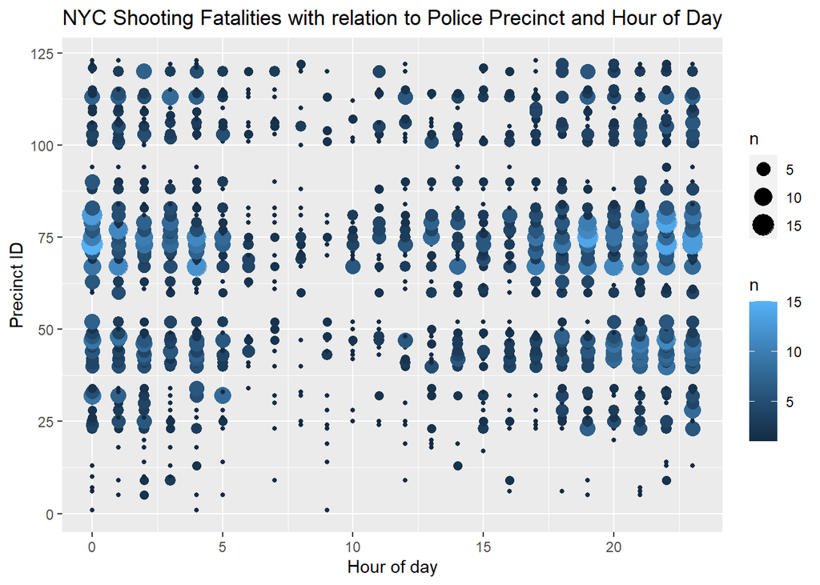

```r
viz1 <- vis_dat %>%
  select(TARGET,PRECINCT, HOUR) %>%
  # We are going to filter for cases which resulted in a fatality.
  filter(TARGET==1) %>%
  count(PRECINCT,HOUR)

# Size and color of the points will vary based on the count of incidents within that specific precinct.
ggplot(data=viz1, aes(x=HOUR,y=PRECINCT, size=n,color=n))+
  geom_point()+
  labs(title='NYC Shooting Fatalities with relation to Police Precinct and Hour of Day', x='Hour of day',y='Precinct ID')
```

After accounting for the count of incidents by precinct and hour, we can determine that the highest concentration of fatal shootings actually takes place in precinct range of 25-85. An interesting observation here is in the difference of time ranges. Precincts in the range of 40-80 experience a relatively safe time frame of only a few hours, between 8am and 10am. Whereas precincts in the range of 25-40 experience very little fatal activity between the hours of 6am and 3pm, however, shooting fatalities pick right back up after 3pm and continue until 5am, which is when it starts to cool down. Another interesting observation here would be the increase in fatalities between the hours of approximately 4pm and 5am, this is especially true for precincts in the range of 100-125.

```r
viz2 <- vis_dat %>%
  select(TARGET,PRECINCT, H_DIST, AREA) %>%
  # We are going to filter for cases which resulted in a fatality.
  #filter(TARGET==0) %>%
  #count(PRECINCT,HOUR)
  mutate(t_pos = if_else(TARGET==1,1,0))%>%
  mutate(t_neg = if_else(TARGET==1,0,1))%>%
  group_by(PRECINCT)%>%
  summarize(
    H_DIST_avr = mean(H_DIST),
    AREA_avr = mean(AREA),
    pos_sum = sum(t_pos),
    neg_sum = sum(t_neg),
    tot_sum = pos_sum+neg_sum,
    pos_percent = pos_sum/tot_sum)

  #mutate(pos_percent_z = (pos_percent-mean(pos_percent))/sd(pos_percent))
head(viz2,5)
```

```
## # A tibble: 5 × 7
##   PRECINCT H_DIST_avr  AREA_avr pos_sum neg_sum tot_sum pos_percent
##      <dbl>      <dbl>     <dbl>   <dbl>   <dbl>   <dbl>       <dbl>
## 1        1      3506. 47286460.       3       7      10      0.3
## 2        5      3091. 18094527.       7      23      30      0.233
## 3        6      2249. 22103327.       4      15      19      0.211
## 4        7      2721. 18366670.       2      52      54      0.0370
## 5        9      1719. 21395386.      13      54      67      0.194
```

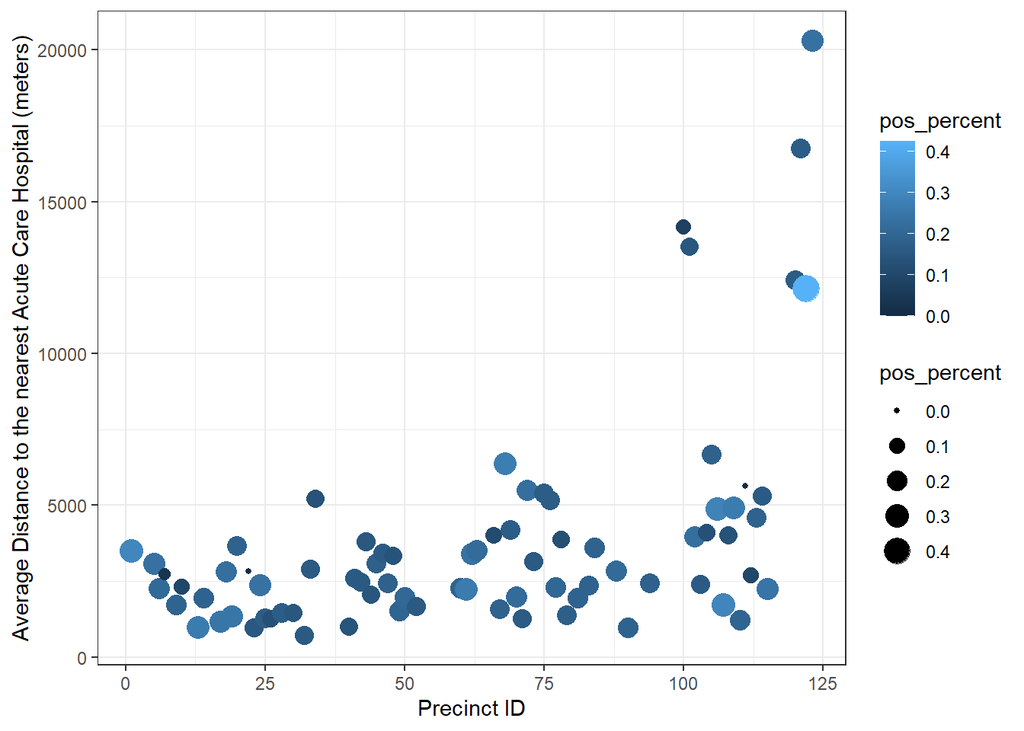

```r
# Size and color of the points will vary based on the count of incidents within that specific precinct.
p1 = ggplot(data=viz2,aes(y=H_DIST_avr,x=PRECINCT, size=pos_percent,color=pos_percent))+
  geom_point()+
  labs(x='Precinct ID',y='Average Distance to the nearest Acute Care Hospital (meters)')+theme_bw()

p2 = ggplot(data=viz2,aes(x=PRECINCT,y=AREA_avr))+
  geom_point()+
  labs(y='Average Area of Police Precinct',x='Precinct ID')+
    theme_bw()


p3 = ggplot(data=viz2,aes(x=PRECINCT,y=pos_percent))+
  geom_point()+
  stat_smooth(method="lm", se=TRUE, formula=y~poly(x,6,raw=TRUE),color='red')+
  labs(y='Fatalities / Total Shootings',x='Precinct ID')+theme_bw()


p1
```

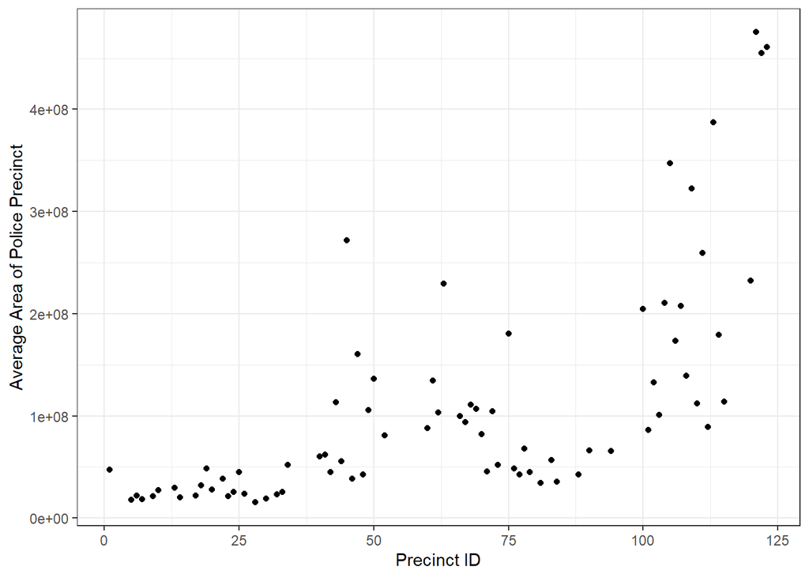

```r
p2
```

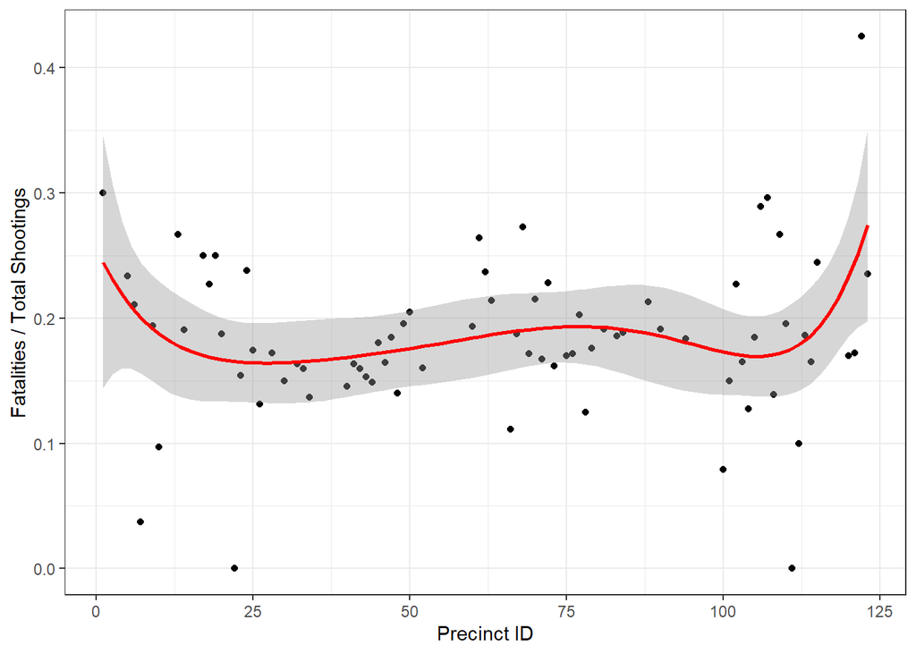

```r
p3
```

Here we can see the percentage of shooting victims who did not survive increases in precincts within a range of 100-125. One potential explanatory variables in determining whether a victim lives or dies could be tied to the hospitals located within or around the precinct in question. This can be observed in precinct ID’s within the range of 100-125, where the average distance to the nearest Acute Care Hospital is 2-3x longer relative to precincts in lower ranges.

```r
vis_dat1 <- vis_dat %>%
  mutate(TAR_POS = if_else(TARGET==1,1,0))%>%
  mutate(TAR_NEG = if_else(TARGET==0,1,0))%>%
  group_by(BORO,Tx)%>%
  summarize(
    tar_pos = sum(TAR_POS),
    tar_neg = sum(TAR_NEG),
    tot_count = (tar_pos+tar_neg),
    pos_rat = tar_pos/tot_count)
head(vis_dat1,5)
```

```
## # A tibble: 5 × 6
## # Groups:   BORO [1]
##   BORO  Tx    tar_pos tar_neg tot_count pos_rat
##   <chr> <fct>   <dbl>   <dbl>     <dbl>   <dbl>
## 1 BRONX T1        143     892      1035   0.138
## 2 BRONX T2        103     505       608   0.169
## 3 BRONX T3         20      92       112   0.179
## 4 BRONX T4         28     109       137   0.204
## 5 BRONX T5         58     219       277   0.209
```

```r
#vis_datx <- train_set2[c(placeholders,cat_vars,num_vars)]
vis_datx1 <- vis_dat1 %>% select(BORO,Tx,tot_count)
head(vis_datx1,5)
```

```
## # A tibble: 5 × 3
## # Groups:   BORO [1]
##   BORO  Tx    tot_count
##   <chr> <fct>     <dbl>
## 1 BRONX T1         1035
## 2 BRONX T2          608
## 3 BRONX T3          112
## 4 BRONX T4          137
## 5 BRONX T5          277
```

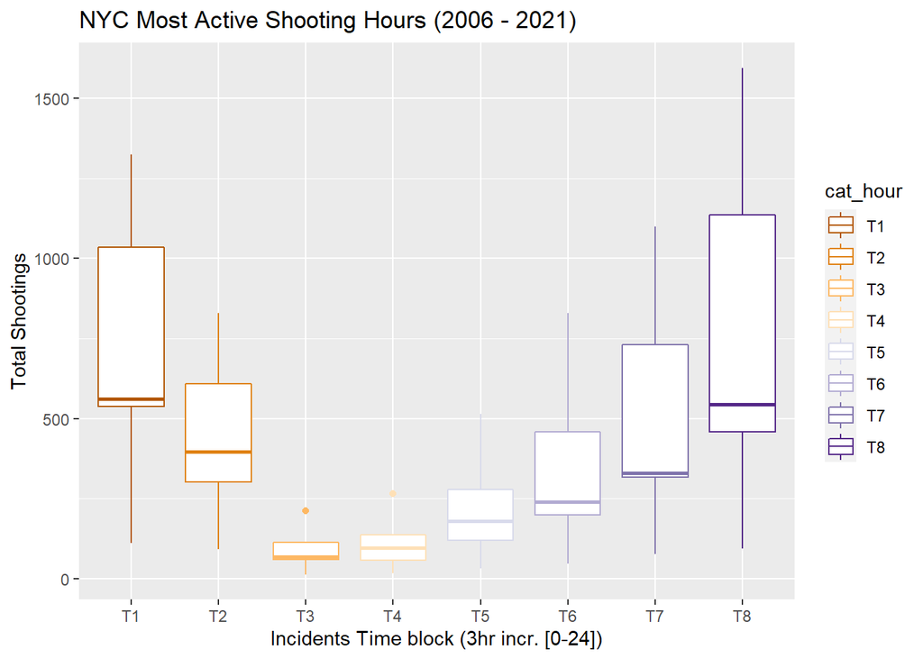

```r
cat_hour = as.factor(vis_datx1$Tx)

ggplot(data=vis_datx1, aes(x=cat_hour,y=tot_count, color=cat_hour)) +
  geom_boxplot()+scale_color_brewer(palette = "PuOr")+
  #geom_jitter(shape=1,position=(position_jitter(0.0)))+
  labs(title = 'NYC Most Active Shooting Hours (2006 - 2021)'
       ,y='Total Shootings',x='Incidents Time block (3hr incr. [0-24])')
```

```r
vis_datx3 <- vis_dat %>%
  select(PRECINCT,BORO,TARGET,AREA,H_DIST,LENGTH,Tx) %>%
  mutate(tar = if_else(TARGET==1,'YES','NO')) %>%
  mutate(YY = if_else(TARGET==1,1,0)) %>%
  mutate(NN = if_else(TARGET==1,0,1)) %>%
  #filter(BORO == 'MANHATTAN'
  group_by(Tx,PRECINCT) %>%
  summarize(#anss = if_else(TARGET==1,"YY","NN"),
            sum_yes = sum(YY),
            sum_no = sum(NN),
            tots = sum_yes+sum_no,
            yes_perc = sum_yes/tots,
            H_DIST_avr = mean(H_DIST),
            AREA_avr = mean(AREA))
```

[output not shown]

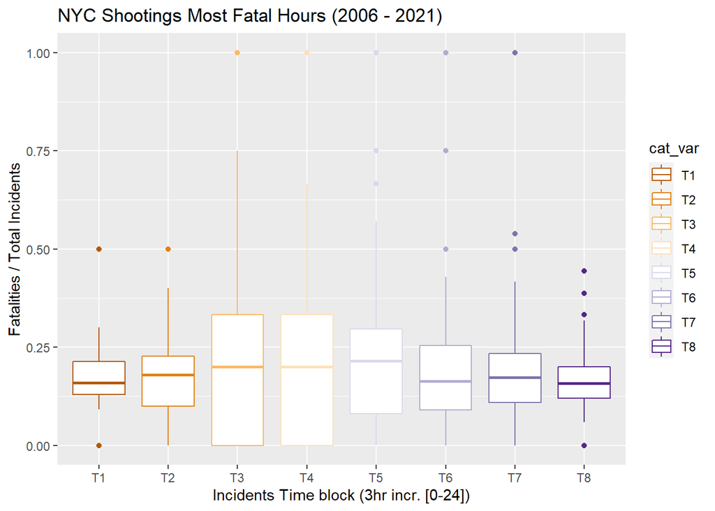

```r
#vis_datx3

t1 <- vis_datx3[,c("Tx","AREA_avr","H_DIST_avr","yes_perc")]


colnames(t1) <- c("Tx", "AREA_avr","H_DIST_avr","yes_perc")
cat_var = as.factor(t1$Tx)
value_var = t1$yes_perc

plot1<- ggplot(data=t1, aes(x=cat_var,y=value_var, color=cat_var)) +
  geom_boxplot()+
  scale_color_brewer(palette = 'PuOr')+
  labs(title = 'NYC Shootings Most Fatal Hours (2006 - 2021)'
       ,y='Fatalities / Total Incidents'
       ,x='Incidents Time block (3hr incr. [0-24])')
plot1
```

One of the factors we could further explore is the time of day the shootings took place. Here we can see that the least active time period for shooters in New York City is between the hours of 6am and 12pm as indicated by time blocks ‘T3’ and ‘T4’ in the model above. These time blocks also carry a much larger interquartile range when it comes to shooting victims who did not survive as seen in the second graph.

- Note: Each ‘T’ in this model is a 3 hour increment starting from 0 and through the 24th hour.

## Modeling Data

- Now we will see if we can build a prediction model given the data we have so far.
- We are going to be using the random forest algorithm as our approach for this model to take advantage of the “Wisdom of the crowds” concept where the collective opinion of many decision trees should yield a relatively better result than relying on a single tree. Furthermore, a random forest approach allows us to take advantage of feature importance in determining which of the variables are actually relevant to the survival of a shooting victim.
  - In taking this approach we are also reducing over-fit bias by averaging the result of many decision trees.

```r
set.seed(123)
selected_vars = c('TARGET','T1','T2','T3','T4','T5','T6','T7','T8','Tx'
             ,'VC_AGE_18','VC_AGE_18_24','VC_AGE_25_44','VC_AGE_65'
             ,'PVT_HOUSE','HOTEL_MOTEL','MULTI_PUB_HOU','MULTI_APT','BAR_CLUB'
             ,'VIC_SEX_M','Latitude','Longitude','AREA','LENGTH','H_DIST')

trainingset <- train_set2%>%select(selected_vars)
```

```
## Note: Using an external vector in selections is ambiguous.
## ℹ Use `all_of(selected_vars)` instead of `selected_vars` to silence this message.
## ℹ See <https://tidyselect.r-lib.org/reference/faq-external-vector.html>.
```

```r
rf <- randomForest(TARGET~.,data = trainingset)

importance(rf)
```

```
##               MeanDecreaseGini
## T1                   12.387934
## T2                   11.648774
## T3                    7.141559
## T4                    6.488401
## T5                    9.549878
## T6                   10.407998
## T7                   12.145852
## T8                   12.910128
## Tx                   67.280654
## VC_AGE_18            25.617892
## VC_AGE_18_24         30.814715
## VC_AGE_25_44          0.000000
## VC_AGE_65             9.288117
## PVT_HOUSE             0.000000
## HOTEL_MOTEL           4.749924
## MULTI_PUB_HOU        27.280254
## MULTI_APT             0.000000
## BAR_CLUB              9.095182
## VIC_SEX_M            24.568745
## Latitude            283.748278
## Longitude           277.711343
## AREA                 94.528773
## LENGTH               95.034046
## H_DIST              282.854307
```

```r
print(rf)
```

```
##
## Call:
##  randomForest(formula = TARGET ~ ., data = trainingset)
##                Type of random forest: classification
##                      Number of trees: 500
## No. of variables tried at each split: 4
##
##         OOB estimate of  error rate: 17.49%
## Confusion matrix:
##       0 1  class.error
## 0 13280 3 0.0002258526
## 1  2813 5 0.9982256920
```

```r
validset<-validation_set%>%select(selected_vars)
pred = predict(rf,newdata=validset[-1])
table(validset[,1],pred)
```

```
##    pred
##        0    1
##   0 3320    1
##   1  703    1
```

```r
accuracy=mean(validset[,1]==pred)
accuracy
```

```
## [1] 0.8250932
```

## Conclusion

There is an evident bias stemming from the imbalance in the positive cases and a lot more work is needed in terms of transformations and model tuning. We also cannot rule out the value of other features from the original (complete) data set and will need to dive deeper into the iterative process of modeling, transforming, and visualizing in order to improve our model performance.